# FLU Prediction based on Symptoms

*Influenza Research Database (IRD) provides a resource for the influenza virus research community that facilitates an understanding of the influenza virus and how it interacts with the host organism, leading to new treatments and preventive actions.*

*Influenza, commonly known as “the flu”, is an infectious disease caused by an influenza virus. High fever, runny nose, sore throat, headache, coughing, etc. are the most common symptoms. These symptoms typically begin two days after exposure to the virus and most last less than a week. Complications of influenza may include viral pneumonia, secondary bacterial pneumonia, sinus infections, and worsening of previous health problems such as asthma or heart failure. Once detected at an earlier stage based on the symptoms, the flu can be treated by getting plenty of rest, drinking plenty of liquids and, take medications to relieve the fever and muscle aches associated with the flu if necessary.*

*By applying statistical methods to this database, we would like to identify if a person is infected by FLU or not infected by FLU based on various factors such as symptoms exhibited by the patient.*

### Loading R-packages

```r
library(readxl)
library("rpart", lib.loc="C:/Program Files/R/R-3.3.3/library")
library("rpart.plot", lib.loc="~/R/win-library/3.3")
library("rattle", lib.loc="~/R/win-library/3.3")
library("RGtk2", lib.loc="~/R/win-library/3.3")
library("randomForest", lib.loc="~/R/win-library/3.3")
library(dplyr)
library(plotrix)
library(car)
library(rpart.plot)
library(rpart)
library(rattle)
library("ggplot2")
library("scales")
library("directlabels")
library("tidyr")
library("RColorBrewer")
library("ROCR")
library(randomForest)
library(class)
```

#### Loading dataset

```r
FluDB <- read_excel("C:/Users/Supriya Khadake/Desktop/SPRING 2018/ITMD 529/ITMD529_Project/Data/FluDB.xlsx")
```

#### Statistical description of the dataset

```r
summary(FluDB)
```

```
##  HostIdentifier       Location              Age           Gender
##  Length:1699        Length:1699        Min.   : 1.0   Min.   :0.000
##  Class :character   Class :character   1st Qu.:19.0   1st Qu.:0.000
##  Mode  :character   Mode  :character   Median :20.0   Median :0.000
##                                        Mean   :28.9   Mean   :0.452
##                                        3rd Qu.:39.5   3rd Qu.:1.000
##                                        Max.   :97.0   Max.   :1.000
##   Temperature     MedicalConditions  RunningNose         Cough
##  Min.   : 96.20   Min.   :0.0000    Min.   :0.0000   Min.   :0.0000
##  1st Qu.: 98.60   1st Qu.:0.0000    1st Qu.:0.0000   1st Qu.:0.0000
##  Median : 99.20   Median :0.0000    Median :1.0000   Median :1.0000
##  Mean   : 99.57   Mean   :0.2831    Mean   :0.5892   Mean   :0.7422
##  3rd Qu.:100.10   3rd Qu.:1.0000    3rd Qu.:1.0000   3rd Qu.:1.0000
##  Max.   :107.24   Max.   :1.0000    Max.   :1.0000   Max.   :1.0000
##     Myalgia          Headache        ThroatAche        Fever
##  Min.   :0.0000   Min.   :0.0000   Min.   :0.000   Min.   :0.0000
##  1st Qu.:0.0000   1st Qu.:0.0000   1st Qu.:0.000   1st Qu.:0.0000
##  Median :1.0000   Median :1.0000   Median :1.000   Median :1.0000
##  Mean   :0.6157   Mean   :0.5244   Mean   :0.528   Mean   :0.6268
##  3rd Qu.:1.0000   3rd Qu.:1.0000   3rd Qu.:1.000   3rd Qu.:1.0000
##  Max.   :1.0000   Max.   :1.0000   Max.   :1.000   Max.   :1.0000
##     Fatigue          Vomiting      FluTestStatus
##  Min.   :0.0000   Min.   :0.0000   Min.   :0.0000
##  1st Qu.:0.0000   1st Qu.:0.0000   1st Qu.:0.0000
##  Median :1.0000   Median :0.0000   Median :1.0000
##  Mean   :0.5827   Mean   :0.4438   Mean   :0.7481
##  3rd Qu.:1.0000   3rd Qu.:1.0000   3rd Qu.:1.0000
##  Max.   :1.0000   Max.   :1.0000   Max.   :1.0000
```

#### Assigning variables

```r
HostIdentifier = FluDB$HostIdentifier
FluDB$Location = as.factor(FluDB$Location)
FluDB$Age = FluDB$Age
FluDB$Gender = as.factor(FluDB$Gender)
FluDB$Temperature = FluDB$Temperature
FluDB$MedicalConditions = as.factor(FluDB$MedicalConditions)
FluDB$RunningNose = as.factor(FluDB$RunningNose)
FluDB$Cough = as.factor(FluDB$Cough)
FluDB$Myalgia = as.factor(FluDB$Myalgia)
FluDB$Headache = as.factor(FluDB$Headache)
FluDB$ThroatAche = as.factor(FluDB$ThroatAche)
FluDB$Fever = as.factor(FluDB$Fever)
FluDB$Fatigue = as.factor(FluDB$Fatigue)
FluDB$Vomiting = as.factor(FluDB$Vomiting)
FluDB$FluTestStatus = as.factor(FluDB$FluTestStatus)
```

#### Splitting data into train(70%) for model selection and test(30%) data for evaluation.

```r
set.seed(42)
FluDB=FluDB[sample(nrow(FluDB)),]
select.data= sample (1:nrow(FluDB), 0.7*nrow(FluDB))
train.data= FluDB[select.data,]
test.data= FluDB[-select.data,]
```

#### To display the number of rows for training and testing data

```r
nrow(test.data)
```

```
## [1] 510
```

```r
nrow(train.data)
```

```
## [1] 1189
```

#### Structure of the train data

```r
str(train.data)
```

```
## Classes 'tbl_df', 'tbl' and 'data.frame':    1189 obs. of  15 variables:
##  $ HostIdentifier   : chr  "NIGSP_FBS_00137" "NIGSP_DOA_00031" "29894949" "F3045C37" ...
##  $ Location         : Factor w/ 42 levels "Alabama","Alaska",..: 21 21 20 37 21 21 21 28 36 28 ...
##  $ Age              : num  27 65 66 20 59 54 21 9 28 25 ...
##  $ Gender           : Factor w/ 2 levels "0","1": 1 2 2 1 2 2 1 2 1 2 ...
##  $ Temperature      : num  99.2 98.2 98.1 98.6 102.6 ...
##  $ MedicalConditions: Factor w/ 2 levels "0","1": 1 1 1 1 2 1 1 2 1 2 ...
##  $ RunningNose      : Factor w/ 2 levels "0","1": 2 2 2 2 1 1 1 2 2 1 ...
##  $ Cough            : Factor w/ 2 levels "0","1": 2 2 2 2 1 1 1 2 2 1 ...
##  $ Myalgia          : Factor w/ 2 levels "0","1": 2 1 2 1 1 1 1 1 2 1 ...
##  $ Headache         : Factor w/ 2 levels "0","1": 2 1 2 1 1 1 1 1 2 1 ...
##  $ ThroatAche       : Factor w/ 2 levels "0","1": 2 1 2 2 1 1 1 2 2 1 ...
##  $ Fever            : Factor w/ 2 levels "0","1": 2 2 1 1 1 1 1 2 2 1 ...
##  $ Fatigue          : Factor w/ 2 levels "0","1": 1 1 2 2 1 1 1 1 2 1 ...
##  $ Vomiting         : Factor w/ 2 levels "0","1": 2 2 2 1 2 2 2 1 2 1 ...
##  $ FluTestStatus    : Factor w/ 2 levels "0","1": 2 2 2 2 2 2 2 1 2 1 ...
```

#### Structure of the test data

```r
str(test.data)
```

```
## Classes 'tbl_df', 'tbl' and 'data.frame':    510 obs. of  15 variables:
##  $ HostIdentifier   : chr  "26575104" "20624618" "21304675" "22950162" ...
##  $ Location         : Factor w/ 42 levels "Alabama","Alaska",..: 5 12 5 10 37 11 28 5 21 37 ...
##  $ Age              : num  33 2 21 45 20 20 50 4 31 20 ...
##  $ Gender           : Factor w/ 2 levels "0","1": 2 2 1 2 2 2 1 2 2 1 ...
##  $ Temperature      : num  99.8 104.6 103 99.2 98.6 ...
##  $ MedicalConditions: Factor w/ 2 levels "0","1": 1 1 1 1 2 1 1 1 2 2 ...
##  $ RunningNose      : Factor w/ 2 levels "0","1": 1 2 1 1 2 2 2 2 1 2 ...
##  $ Cough            : Factor w/ 2 levels "0","1": 2 2 2 2 2 2 2 2 2 2 ...
##  $ Myalgia          : Factor w/ 2 levels "0","1": 2 2 2 2 1 2 2 2 1 2 ...
##  $ Headache         : Factor w/ 2 levels "0","1": 1 2 1 2 1 2 1 2 1 1 ...
##  $ ThroatAche       : Factor w/ 2 levels "0","1": 1 2 1 2 1 2 2 1 1 2 ...
##  $ Fever            : Factor w/ 2 levels "0","1": 2 2 2 2 1 2 1 2 2 2 ...
##  $ Fatigue          : Factor w/ 2 levels "0","1": 2 2 2 2 2 2 2 2 1 2 ...
##  $ Vomiting         : Factor w/ 2 levels "0","1": 1 2 1 1 1 1 1 1 2 1 ...
##  $ FluTestStatus    : Factor w/ 2 levels "0","1": 2 2 2 2 2 2 2 2 2 2 ...
```

### Exploratory Data Analysis

Exploratory Data Analysis(EDA) is a critical step by which team discovered which parameters are most significant in determining the desired outcome. In our case we are trying to predict FLU based on symptoms and its more important to know which symptoms affect the most or if any of the symptom is least important and does not make any difference. With the help of plots for scenario of FluTestStatus as positive it was known that all of the 8 symptoms are relevant

#### Considering only patients having FLU

```r
FluDB_histogram=filter(FluDB,FluTestStatus==1)
```

### Quantitative Variables (Continuous Predictors)

Our current data includes Age and Temperature as Numeric variables. From the plots we observed that people within Age group 10 to 20 and temperature between 99 to 100 has FLU status as positive. Also, we saw that as Age increases the frequency of Flustatus being positive decreases

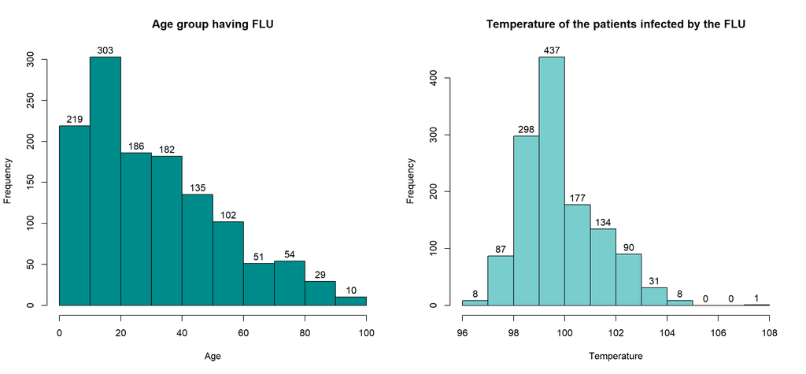

```r
par(mfrow=c(1,2))
hist_age = hist(FluDB_histogram$Age, col = "cyan4", xlab="Age", main = "Age group having FLU" )
text(hist_age$mids, hist_age$counts, labels = hist_age$counts, adj=c(0.5, -0.5))

hist_temp = hist(FluDB_histogram$Temperature, col="darkslategray3", xlab="Temperature", main = "Temperature of the patients infected by the FLU")
text(hist_temp$mids, hist_temp$counts, labels = hist_temp$counts, adj=c(0.5, -0.5))
```

***

### Qualitative Variables (Categorical Predictors)

Histogram for Gender and Medical Conditions with Flu Status as positive: We can see that female are more to have FLU status as positive and medical condition does not affect that much. Also, Female are more susceptable to flu but differ against the range of men marginally

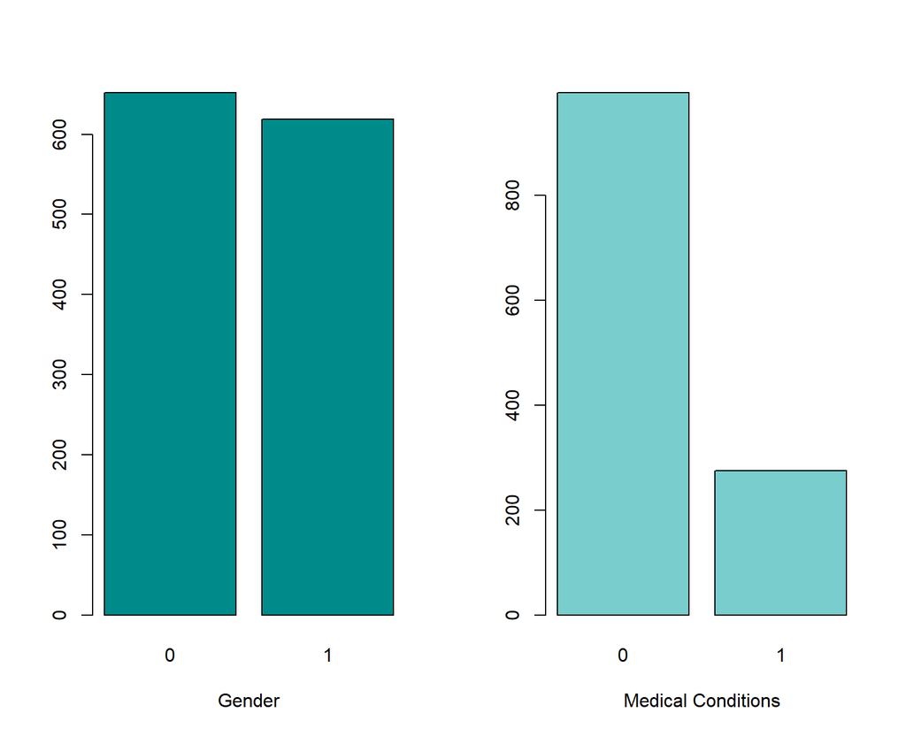

```r
par(mfrow=c(1,2))
plot_gender = plot(FluDB_histogram$Gender,col="cyan4",xlab="Gender")
plot(FluDB_histogram$MedicalConditions,col="darkslategray3",xlab="Medical Conditions")
```

***

### Histogram for all the symptoms with Flu Status as positive:

This shows, most of these symptoms can indicate that a person is suffering from flu.

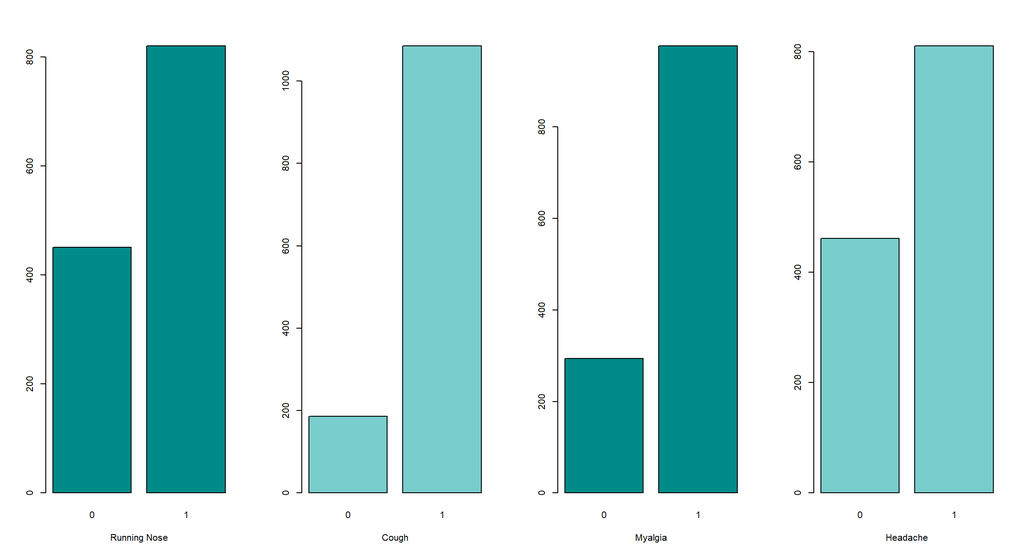

```r
par(mfrow=c(1,4))
plot(FluDB_histogram$RunningNose,col="cyan4",xlab="Running Nose")
plot(FluDB_histogram$Cough,col="darkslategray3",xlab="Cough")
plot(FluDB_histogram$Myalgia,col="cyan4",xlab="Myalgia")
plot(FluDB_histogram$Headache,col="darkslategray3",xlab="Headache")
```

***

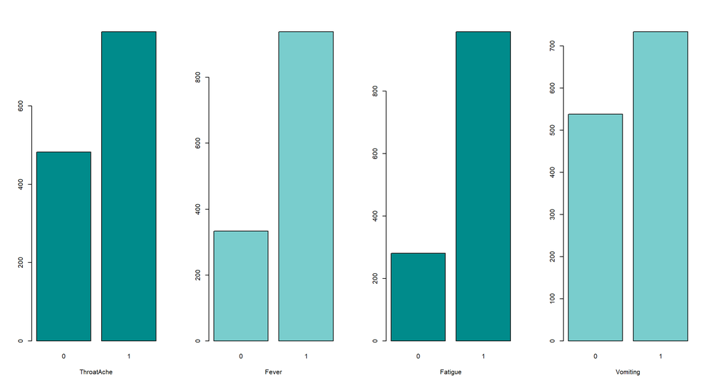

```r
par(mfrow=c(1,4))
plot(FluDB_histogram$ThroatAche,col="cyan4",xlab="ThroatAche")
plot(FluDB_histogram$Fever,col="darkslategray3",xlab="Fever")
plot(FluDB_histogram$Fatigue,col="cyan4",xlab="Fatigue")
plot(FluDB_histogram$Vomiting,col="darkslategray3",xlab="Vomiting")
```

***

### Histogram for location with Flu Status as positive:

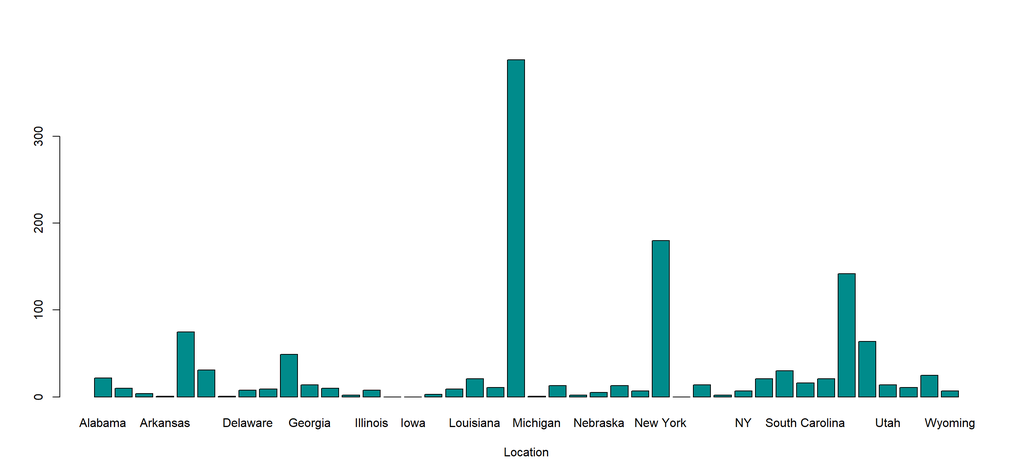

```r
par(mfrow=c(1,1))
plot(FluDB_histogram$Location,col="cyan4",xlab="Location")
```

***

### Logistic Regression Model

Building model considering all the variables

```r
log0 = glm(FluTestStatus ~ Location + Age + Temperature + Gender + MedicalConditions + RunningNose + Cough
         + Myalgia + Headache + ThroatAche + Fever + Fatigue + Vomiting, data = train.data, family = "binomial")
summary(log0)
```

```
##
## Call:
## glm(formula = FluTestStatus ~ Location + Age + Temperature +
##     Gender + MedicalConditions + RunningNose + Cough + Myalgia +
##     Headache + ThroatAche + Fever + Fatigue + Vomiting, family = "binomial",
##     data = train.data)
##
## Deviance Residuals:
##       Min         1Q     Median         3Q        Max
## -5.43e-04   2.00e-08   2.00e-08   2.00e-08   4.89e-04
##
## Coefficients:
##                                Estimate Std. Error z value Pr(>|z|)
## (Intercept)                   -3648.217 335569.617  -0.011    0.991
## LocationAlaska                 -266.883  93697.319  -0.003    0.998
## LocationArizona                -474.698 224354.857  -0.002    0.998
## LocationCalifornia             -215.344  67780.841  -0.003    0.997
## LocationColorado               -130.998  83097.039  -0.002    0.999
## LocationConnecticut            -184.016 360772.174  -0.001    1.000
## LocationDelaware               -400.227  68842.347  -0.006    0.995
## LocationDistrict of Columbia   -287.334 125849.911  -0.002    0.998
## LocationFlorida                -178.595  54745.883  -0.003    0.997
## LocationGeorgia                -244.976  79297.791  -0.003    0.998
## LocationHawaii                 -392.101  84435.058  -0.005    0.996
## LocationIdaho                  -519.373  77335.881  -0.007    0.995
## LocationIllinois                 23.379 115777.330   0.000    1.000
## LocationIndiana                 -12.034 360280.873   0.000    1.000
## LocationIowa                    -21.370 239785.001   0.000    1.000
## LocationKansas                 -186.042 159943.956  -0.001    0.999
## LocationKentucky               -271.966 115315.578  -0.002    0.998
## LocationLouisiana               -84.213  93017.092  -0.001    0.999
## LocationMaryland               -298.733 103035.114  -0.003    0.998
## LocationMassachusetts           242.027  57768.687   0.004    0.997
## LocationMichigan                 14.962 360506.621   0.000    1.000
## LocationMississippi            -232.861  94763.804  -0.002    0.998
## LocationMontana                -360.527 178293.399  -0.002    0.998
## LocationNebraska               -524.594 170460.628  -0.003    0.998
## LocationNevada                    1.307  97503.533   0.000    1.000
## LocationNew Jersey             -364.132 120725.295  -0.003    0.998
## LocationNew York               -166.955  52027.203  -0.003    0.997
```

[output cut: 19 more lines]

```
## Cough1                           -0.214  13082.398   0.000    1.000
## Myalgia1                        100.202  15411.519   0.007    0.995
## Headache1                       -93.967  19645.102  -0.005    0.996
## ThroatAche1                       1.326  13935.623   0.000    1.000
## Fever1                           75.281   4980.898   0.015    0.988
## Fatigue1                        359.817  27965.582   0.013    0.990
## Vomiting1                        93.754  13445.140   0.007    0.994
##
## (Dispersion parameter for binomial family taken to be 1)
##
##     Null deviance: 1.3256e+03  on 1188  degrees of freedom
## Residual deviance: 9.5215e-07  on 1136  degrees of freedom
## AIC: 106
##
## Number of Fisher Scoring iterations: 25
```

#### Without Location

By individual parameter we can see that location is not sugnificant to the response variable Hence we will go ahead and eliminate the same and rebuild model.

```r
log1 = glm(FluTestStatus ~ Age + Temperature + Gender + MedicalConditions + RunningNose + Cough
+ Myalgia + Headache + ThroatAche + Fever + Fatigue + Vomiting, data = train.data, family = "binomial")
summary(log1)
```

```
##
## Call:
## glm(formula = FluTestStatus ~ Age + Temperature + Gender + MedicalConditions +
##     RunningNose + Cough + Myalgia + Headache + ThroatAche + Fever +
##     Fatigue + Vomiting, family = "binomial", data = train.data)
##
## Deviance Residuals:
##      Min        1Q    Median        3Q       Max
## -2.67968   0.00000   0.00000   0.00001   2.77763
##
## Coefficients:
##                      Estimate Std. Error z value Pr(>|z|)
## (Intercept)        -165.89466   39.22888  -4.229 2.35e-05 ***
## Age                   0.07246    0.01905   3.803 0.000143 ***
## Temperature           1.62908    0.39685   4.105 4.04e-05 ***
## Gender1               0.54991    0.51507   1.068 0.285681
## MedicalConditions1   -1.66006    0.65734  -2.525 0.011556 *
## RunningNose1         -3.74707    0.88840  -4.218 2.47e-05 ***
## Cough1                2.30354    0.80135   2.875 0.004046 **
## Myalgia1              3.69682    0.75212   4.915 8.87e-07 ***
## Headache1            -3.21147    0.77152  -4.163 3.15e-05 ***
## ThroatAche1          -0.25760    0.64097  -0.402 0.687758
## Fever1                0.15756    0.64395   0.245 0.806704
## Fatigue1             27.45624 1289.07968   0.021 0.983007
## Vomiting1             5.12686    0.67512   7.594 3.10e-14 ***
## ---
## Signif. codes:  0 '***' 0.001 '**' 0.01 '*' 0.05 '.' 0.1 ' ' 1
##
## (Dispersion parameter for binomial family taken to be 1)
##
##     Null deviance: 1325.57  on 1188  degrees of freedom
## Residual deviance:  129.38  on 1176  degrees of freedom
## AIC: 155.38
##
## Number of Fisher Scoring iterations: 21
```

#### Without Location & Eliminating Fatigue

```r
log2 = glm(FluTestStatus ~ Age + Temperature + Gender + MedicalConditions + RunningNose + Cough
+ Myalgia + Headache + ThroatAche + Fever + Vomiting, data = train.data, family = "binomial")
summary(log2)
```

```
##
## Call:
## glm(formula = FluTestStatus ~ Age + Temperature + Gender + MedicalConditions +
##     RunningNose + Cough + Myalgia + Headache + ThroatAche + Fever +
##     Vomiting, family = "binomial", data = train.data)
##
## Deviance Residuals:
##      Min        1Q    Median        3Q       Max
## -2.99227   0.02049   0.14022   0.33130   2.45939
##
## Coefficients:
##                      Estimate Std. Error z value Pr(>|z|)
## (Intercept)        -59.476671  17.158606  -3.466 0.000528 ***
## Age                  0.035049   0.008312   4.216 2.48e-05 ***
## Temperature          0.584706   0.173951   3.361 0.000776 ***
## Gender1              0.542447   0.216719   2.503 0.012315 *
## MedicalConditions1  -1.252354   0.238135  -5.259 1.45e-07 ***
## RunningNose1        -1.006205   0.335387  -3.000 0.002699 **
## Cough1               0.649795   0.336868   1.929 0.053740 .
## Myalgia1             2.648444   0.357305   7.412 1.24e-13 ***
## Headache1           -0.134670   0.340879  -0.395 0.692795
## ThroatAche1         -0.083058   0.304308  -0.273 0.784898
## Fever1               0.527624   0.287314   1.836 0.066298 .
## Vomiting1            2.636377   0.326497   8.075 6.76e-16 ***
## ---
## Signif. codes:  0 '***' 0.001 '**' 0.01 '*' 0.05 '.' 0.1 ' ' 1
##
## (Dispersion parameter for binomial family taken to be 1)
##
##     Null deviance: 1325.57  on 1188  degrees of freedom
## Residual deviance:  604.17  on 1177  degrees of freedom
## AIC: 628.17
##
## Number of Fisher Scoring iterations: 7
```

#### Without Location & Eliminating ThroatAche

```r
log3 = glm(FluTestStatus ~ Age + Temperature + Gender + MedicalConditions + RunningNose + Cough
+ Myalgia + Headache + Fever + Vomiting, data = train.data, family = "binomial")
summary(log3)
```

```
##
## Call:
## glm(formula = FluTestStatus ~ Age + Temperature + Gender + MedicalConditions +
##     RunningNose + Cough + Myalgia + Headache + Fever + Vomiting,
##     family = "binomial", data = train.data)
##
## Deviance Residuals:
##      Min        1Q    Median        3Q       Max
## -2.99705   0.02031   0.13976   0.33481   2.46839
##
## Coefficients:
##                      Estimate Std. Error z value Pr(>|z|)
## (Intercept)        -59.506004  17.181134  -3.463 0.000533 ***
## Age                  0.034901   0.008285   4.213 2.52e-05 ***
## Temperature          0.584995   0.174179   3.359 0.000783 ***
## Gender1              0.547599   0.215954   2.536 0.011222 *
## MedicalConditions1  -1.249009   0.237608  -5.257 1.47e-07 ***
## RunningNose1        -1.018636   0.332355  -3.065 0.002177 **
## Cough1               0.635913   0.332484   1.913 0.055798 .
## Myalgia1             2.628361   0.349117   7.529 5.13e-14 ***
## Headache1           -0.150284   0.336128  -0.447 0.654800
## Fever1               0.517800   0.285161   1.816 0.069398 .
## Vomiting1            2.643170   0.325757   8.114 4.90e-16 ***
## ---
## Signif. codes:  0 '***' 0.001 '**' 0.01 '*' 0.05 '.' 0.1 ' ' 1
##
## (Dispersion parameter for binomial family taken to be 1)
##
##     Null deviance: 1325.57  on 1188  degrees of freedom
## Residual deviance:  604.25  on 1178  degrees of freedom
## AIC: 626.25
##
## Number of Fisher Scoring iterations: 7
```

#### Without Location & Eliminating Headache

```r
log4 = glm(FluTestStatus ~ Age + Temperature + Gender + MedicalConditions + RunningNose + Cough
+ Myalgia + Fever + Vomiting, data = train.data, family = "binomial")
summary(log4)
```

```
##
## Call:
## glm(formula = FluTestStatus ~ Age + Temperature + Gender + MedicalConditions +
##     RunningNose + Cough + Myalgia + Fever + Vomiting, family = "binomial",
##     data = train.data)
##
## Deviance Residuals:
##      Min        1Q    Median        3Q       Max
## -3.00907   0.02072   0.13940   0.33039   2.41355
##
## Coefficients:
##                      Estimate Std. Error z value Pr(>|z|)
## (Intercept)        -59.264613  17.153263  -3.455 0.000550 ***
## Age                  0.034805   0.008273   4.207 2.59e-05 ***
## Temperature          0.582549   0.173892   3.350 0.000808 ***
## Gender1              0.544956   0.215806   2.525 0.011563 *
## MedicalConditions1  -1.247227   0.237763  -5.246 1.56e-07 ***
## RunningNose1        -1.025265   0.331767  -3.090 0.001999 **
## Cough1               0.612714   0.328177   1.867 0.061898 .
## Myalgia1             2.536440   0.279520   9.074  < 2e-16 ***
## Fever1               0.534606   0.282456   1.893 0.058397 .
## Vomiting1            2.637572   0.326338   8.082 6.35e-16 ***
## ---
## Signif. codes:  0 '***' 0.001 '**' 0.01 '*' 0.05 '.' 0.1 ' ' 1
##
## (Dispersion parameter for binomial family taken to be 1)
##
##     Null deviance: 1325.57  on 1188  degrees of freedom
## Residual deviance:  604.45  on 1179  degrees of freedom
## AIC: 624.45
##
## Number of Fisher Scoring iterations: 7
```

#### Calculating McFadden’s R square value

```r
nullmodel=glm(FluDB$FluTestStatus~1,family="binomial")
1-logLik(log1)/logLik(nullmodel)
```

```
## 'log Lik.' 0.9325428 (df=13)
```

```r
1-logLik(log2)/logLik(nullmodel)
```

```
## 'log Lik.' 0.6849853 (df=12)
```

```r
1-logLik(log3)/logLik(nullmodel)
```

```
## 'log Lik.' 0.6849463 (df=11)
```

```r
1-logLik(log4)/logLik(nullmodel)
```

```
## 'log Lik.' 0.6848405 (df=10)
```

#### Let’s check multicollinearity for best model

```r
vif(log1)
```

```
##               Age       Temperature            Gender MedicalConditions
##          1.608605          2.243752          1.153416          1.609020
##       RunningNose             Cough           Myalgia          Headache
##          3.612213          2.725120          2.587940          2.334393
##        ThroatAche             Fever           Fatigue          Vomiting
##          1.857177          1.858602          1.000001          2.064873
```

### Decision Tree

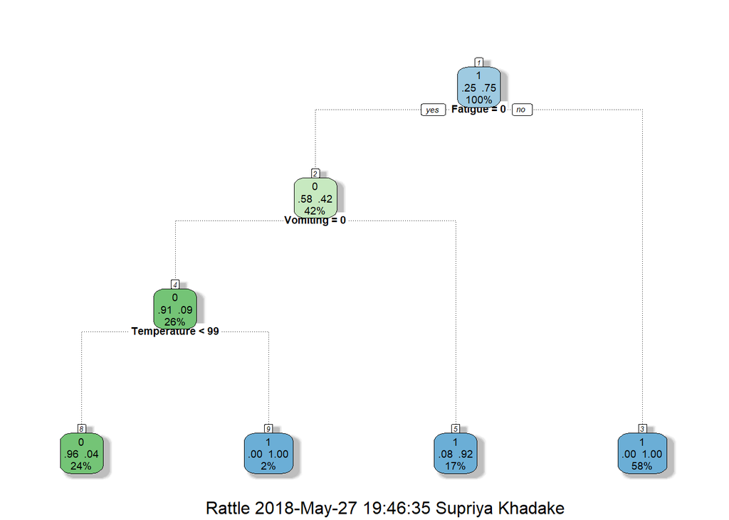

```r
model10 = rpart(FluTestStatus ~ Age + Temperature + Gender + MedicalConditions + RunningNose + Cough+ Myalgia + Headache + ThroatAche + Fever + Fatigue + Vomiting, data = train.data, method = "class")
fancyRpartPlot(model10, cex=.58)
```

***

#### Constructing confusion matrix and checking accuracy of the model

```r
# Make predictions on the testing set -- Model10
my_prediction10 <- predict(model10, test.data, type = "vector")
# Finish the data.frame() call
my_solution10 <- data.frame(ID = test.data$HostIdentifier, flu10 = my_prediction10)
#Generation of Confusion Matrix
conf10 = table(test.data$FluTestStatus, my_solution10$flu10)
conf10
```

```
##
##       1   2
##   0 130   6
##   1   4 370
```

```r
acc10 = sum(diag(conf10))/sum(conf10)
acc10
```

```
## [1] 0.9803922
```

#### ROC Curve

```r
pred <- prediction(my_prediction10, test.data$FluTestStatus)

performance(pred, "auc")
```

```
## An object of class "performance"
## Slot "x.name":
## [1] "None"
##
## Slot "y.name":
## [1] "Area under the ROC curve"
##
## Slot "alpha.name":
## [1] "none"
##
## Slot "x.values":
## list()
##
## Slot "y.values":
## [[1]]
## [1] 0.9725936
##
##
## Slot "alpha.values":
## list()
```

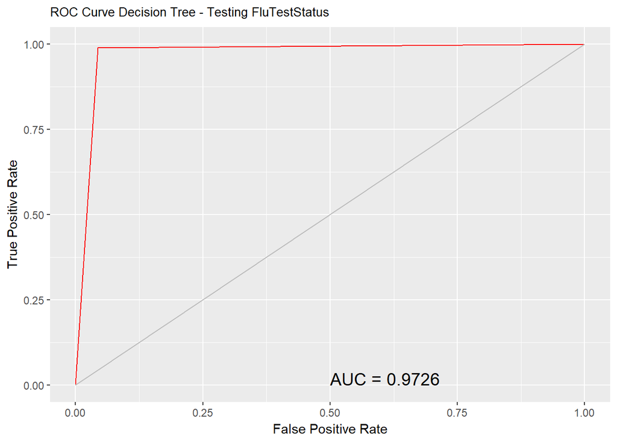

```r
pe <- performance(pred, "tpr", "fpr")
au <- performance(pred, "auc")@y.values[[1]]
pd <- data.frame(fpr=unlist(pe@x.values), tpr=unlist(pe@y.values))
p <- ggplot(pd, aes(x=fpr, y=tpr))
p <- p + geom_line(colour="red")
p <- p + xlab("False Positive Rate") + ylab("True Positive Rate")
p <- p + ggtitle("ROC Curve Decision Tree - Testing FluTestStatus")
p <- p + theme(plot.title=element_text(size=10))
p <- p + geom_line(data=data.frame(), aes(x=c(0,1), y=c(0,1)), colour="grey")
p <- p + annotate("text", x=0.50, y=0.00, hjust=0, vjust=0, size=5,
                  label=paste("AUC =", round(au, 4)))
print(p)
```

***

### Random Forest

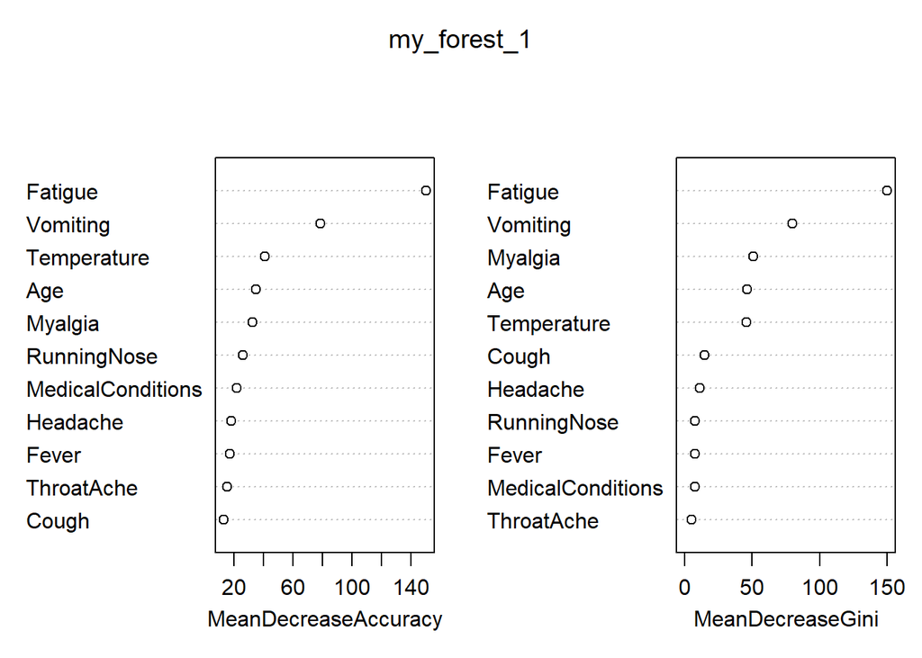

```r
my_forest_1 <- randomForest(FluTestStatus ~ Age + Temperature + MedicalConditions + RunningNose + Cough
+ Myalgia + Headache + ThroatAche + Fever + Fatigue + Vomiting, train.data, ntree=1000, importance=TRUE)
varImpPlot(my_forest_1)
```

***

#### Make predictions on the testing set - my_forest_1 without location

```r
my_prediction_1 <- predict(my_forest_1, test.data)
# Make predictions on the testing set -- my_forest_1
my_solution_1 <- data.frame(ID = test.data$HostIdentifier, forest1 = my_prediction_1)
#Generation of Confusion Matrix
conf_1 <- table(test.data$FluTestStatus,my_solution_1$forest1)
conf_1
```

```
##
##       0   1
##   0 135   1
##   1   2 372
```

```r
acc_1 = sum(diag(conf_1))/sum(conf_1)
acc_1
```

```
## [1] 0.9941176
```

### KNN Classifier

```r
train_label=train.data$FluTestStatus
test_label=test.data$FluTestStatus
```

```r
#Copying train and test data to knn_train and knn_test
knn_train <- train.data
knn_test <- test.data
```

```r
#Dropping FLUTestStatus column for knn_train and knn_test
knn_train$FluTestStatus <- NULL
knn_test$FluTestStatus <- NULL

# Not Considering Location
knn_train$Location <- NULL
knn_test$Location <- NULL

# Not Considering HostIdentifier
knn_train$HostIdentifier <- NULL
knn_test$HostIdentifier <- NULL

#Normalizing Age
min_age <- min(knn_train$Age)
max_age <- max(knn_train$Age)
knn_train$Age <- (knn_train$Age - min_age)/(max_age - min_age)
knn_test$Age <- (knn_test$Age - min_age)/(max_age - min_age)

#Normalizing Temperature
max_temp <- max(knn_train$Temperature)
min_temp <- min(knn_train$Temperature)
knn_train$Temperature <- (knn_train$Temperature - min_temp)/(max_temp - min_temp)
knn_test$Temperature <- (knn_test$Temperature - min_temp)/(max_temp - min_temp)

# Determing best K-value using accuracy
range=1:round(0.2* nrow(knn_train))
accs= rep(0, length(range))
for(k in range) {knn_pred = knn(knn_train, knn_test, cl=train_label, k=k)
knn_conf <- table(test_label, knn_pred)
knn_conf
accs[k] = sum(diag(knn_conf))/sum(knn_conf)}
accs[k]
```

```
## [1] 0.8980392
```

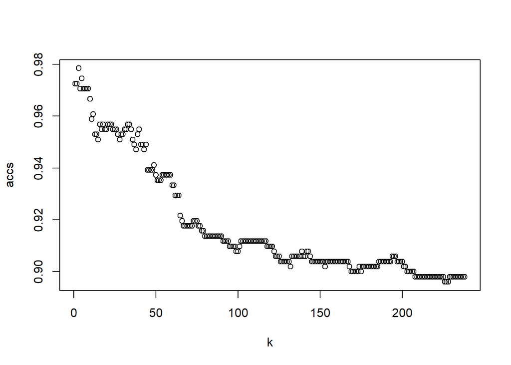

```r
plot(range, accs, xlab="k")
```

```r
which.max(accs)
```

```
## [1] 3
```

#### From the above graph we can see that as value of k increases the Accuracy of the model decreases. The Accuracy of the model can be obtained highest at k = 1 to 5

Hence, checing for k = 10 and k = 3 From the below we proved that as value of k increases the accuracy of the model decreases

```r
knn_pred = knn(knn_train, knn_test, train_label, k=10, prob=TRUE)
knn_conf<- table(test_label, knn_pred)
knn_conf
```

```
##           knn_pred
## test_label   0   1
##          0 122  14
##          1   5 369
```

```r
sum(diag(knn_conf))/sum(knn_conf)
```

```
## [1] 0.9627451
```

```r
knn_pred1 = knn(knn_train, knn_test, train_label, k=3, prob=TRUE)
knn_conf1 <- table(test_label, knn_pred1)
knn_conf1
```

```
##           knn_pred1
## test_label   0   1
##          0 128   8
##          1   3 371
```

```r
sum(diag(knn_conf1))/sum(knn_conf1)
```

```
## [1] 0.9784314
```

### Model Definition and Preparation

Now, Considering p=P(Y=1) as probability of Y which is FluTestStatus. Hence we will set the threshold to 0.5 in order to determine the odds of Y happening a) For odd>1 then pr(Y=1) > Pr(Y=0) -> Pr(Y=1) > 0.5 b) For odd<1 then p=pr(Y=1) < Pr(Y=0) -> Pr(Y=1) < 0.5 c) For odd=1 then Pr(Y=1) = Pr(Y=0) -> Pr(Y=1)=0.5 We can do this by considering one row from the test.data

```r
head(test.data)
```

```
## # A tibble: 6 x 15
##   HostIdentifier Location     Age Gender Temperature MedicalConditions
##   <chr>          <fct>      <dbl> <fct>        <dbl> <fct>
## 1 26575104       California    33 1             99.8 0
## 2 20624618       Hawaii         2 1            105.  0
## 3 21304675       California    21 0            103   0
## 4 22950162       Florida       45 1             99.2 0
## 5 F1087          Tennessee     20 1             98.6 1
## 6 25838675       Georgia       20 1            101.  0
## # ... with 9 more variables: RunningNose <fct>, Cough <fct>,
## #   Myalgia <fct>, Headache <fct>, ThroatAche <fct>, Fever <fct>,
## #   Fatigue <fct>, Vomiting <fct>, FluTestStatus <fct>
```

Considering row one, we will substitute these values in the equation obtained to determine the output.

```r
exp(-2.104)/1+exp(-2.104)
```

```
## [1] 0.2439352
```